# Word Learning

Kimberly A. Brink

June 06, 2017

“Word Learning” is a study that assesses whether children will selectively trust a robot that provides accurate information compared to a robot that provides inaccurate information. Children watch two robots name a series of familiar objects, where one robot always names the object correctly and the other robot always incorrectly names the robot. The two robots are distingushed by their colors.

There were 2 no shows. There were 1 cancelled appointments There were 5 fuss outs.

## Demographics

There are 67 participants.

The average age of the sample is 42.56 months.

The median age of the sample is 41.87 months.

The minimum age of the sample is 36.4 months.

The maximum age of the sample is 48 months.

There are 36 females in the sample.

The first date of test was 2016-03-09.

The most recent date of test was 2016-11-16.

Age(months)

| Min. | 1st Qu. | Median | Mean | 3rd Qu. | Max. |
| --- | --- | --- | --- | --- | --- |
| 36.4 | 39.67 | 41.87 | 42.56 | 45.8 | 48 |

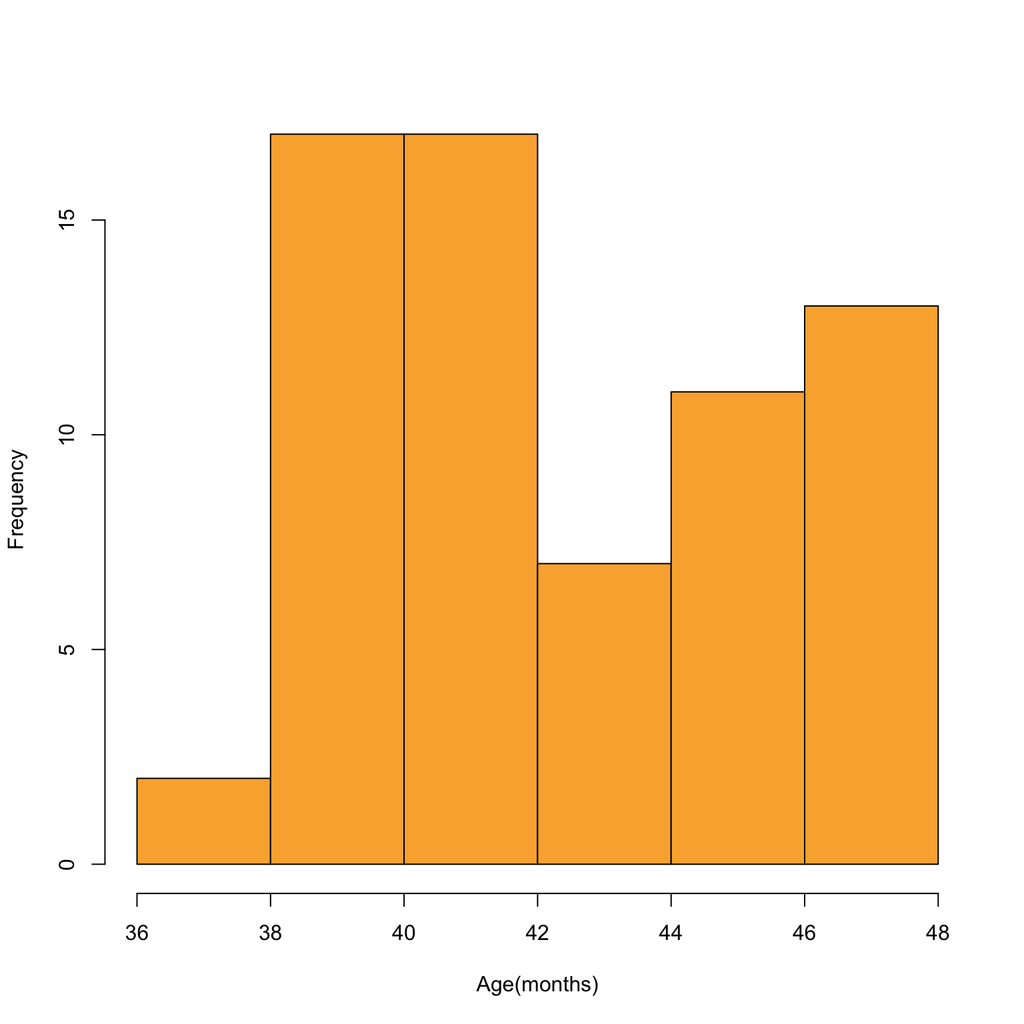

Age(years)

| Min. | 1st Qu. | Median | Mean | 3rd Qu. | Max. |
| --- | --- | --- | --- | --- | --- |
| 3.033 | 3.306 | 3.489 | 3.547 | 3.817 | 4 |

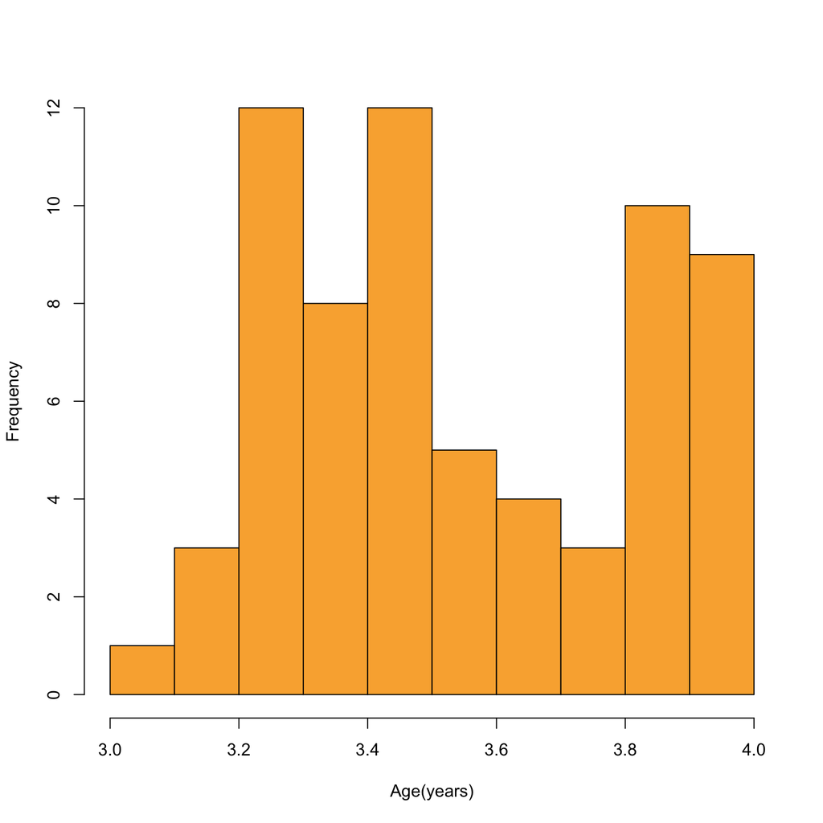

Distribution by Order of Presentation

| A | B | C | D |
| --- | --- | --- | --- |
| 16 | 17 | 15 | 19 |

## Performance during accuracy trials

| Min. | 1st Qu. | Median | Mean | 3rd Qu. | Max. |
| --- | --- | --- | --- | --- | --- |
| 2 | 4 | 4 | 3.896 | 4 | 4 |

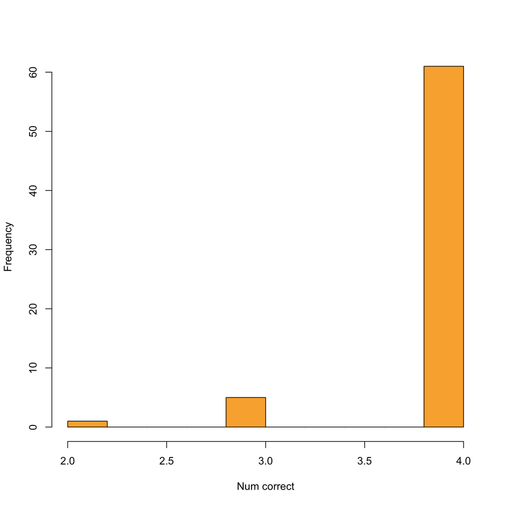

Participant Count by Number of Trials Correct

| 2 | 3 | 4 |
| --- | --- | --- |
| 1 | 5 | 61 |

Distribution by Order of Presentation after removing for familiarization

| A | B | C | D |
| --- | --- | --- | --- |
| 16 | 17 | 12 | 16 |

Now there are 61 participants after removing for familiarization errors.

```
##
##  Welch Two Sample t-test
##
## data:  WL1$Total by WL1$Sex
## t = -0.35, df = 59, p-value = 0.7
## alternative hypothesis: true difference in means is not equal to 0
## 95 percent confidence interval:
##  -0.10164  0.07129
## sample estimates:
## mean in group Female   mean in group Male
##               0.6342               0.6494
```

Analysis of Variance Model

|  | Df | Sum Sq | Mean Sq | F value | Pr(>F) |
| --- | --- | --- | --- | --- | --- |
| **Order** | 3 | 0.2602 | 0.08672 | 3.238 | 0.02866 |
| **Residuals** | 57 | 1.526 | 0.02678 | NA | NA |

|  | Estimate | Std. Error | t value | Pr(>\|t\|) |
| --- | --- | --- | --- | --- |
| **OrderB** | -0.05902 | 0.05735 | -1.029 | 0.3078 |
| **OrderC** | 0.05639 | 0.06288 | 0.8967 | 0.3737 |
| **OrderD** | 0.1104 | 0.05809 | 1.9 | 0.06257 |
| **Age** | 0.006371 | 0.006745 | 0.9446 | 0.3489 |
| **(Intercept)** | 0.3457 | 0.2861 | 1.208 | 0.232 |

(Dispersion parameter for gaussian family taken to be 0.02683 )

| Null deviance: | 1.787 on 60 degrees of freedom |
| --- | --- |
| Residual deviance: | 1.502 on 56 degrees of freedom |

|  | Estimate | Std. Error | t value | Pr(>\|t\|) |
| --- | --- | --- | --- | --- |
| **OrderB** | -0.08955 | 0.058 | -1.544 | 0.1293 |
| **OrderC** | -0.02248 | 0.06471 | -0.3474 | 0.7298 |
| **OrderD** | 0.04548 | 0.06096 | 0.7461 | 0.4593 |
| **AgIndex** | 0.07347 | 0.02433 | 3.02 | 0.004075 |
| **(Intercept)** | 0.5237 | 0.05646 | 9.276 | 0.000000000003414 |

(Dispersion parameter for gaussian family taken to be 0.02323 )

| Null deviance: | 1.510 on 51 degrees of freedom |
| --- | --- |
| Residual deviance: | 1.092 on 47 degrees of freedom |

Total Correct Breakdown

| Min. | 1st Qu. | Median | Mean | 3rd Qu. | Max. |
| --- | --- | --- | --- | --- | --- |
| 0.125 | 0.5 | 0.625 | 0.6407 | 0.7778 | 1 |

*0.1726*

# Comparisons with chance for three test questions.

Proportion of Explicit Judgment Questions Correct

| Min. | 1st Qu. | Median | Mean | 3rd Qu. | Max. |
| --- | --- | --- | --- | --- | --- |
| 0 | 1 | 1 | 0.8607 | 1 | 1 |

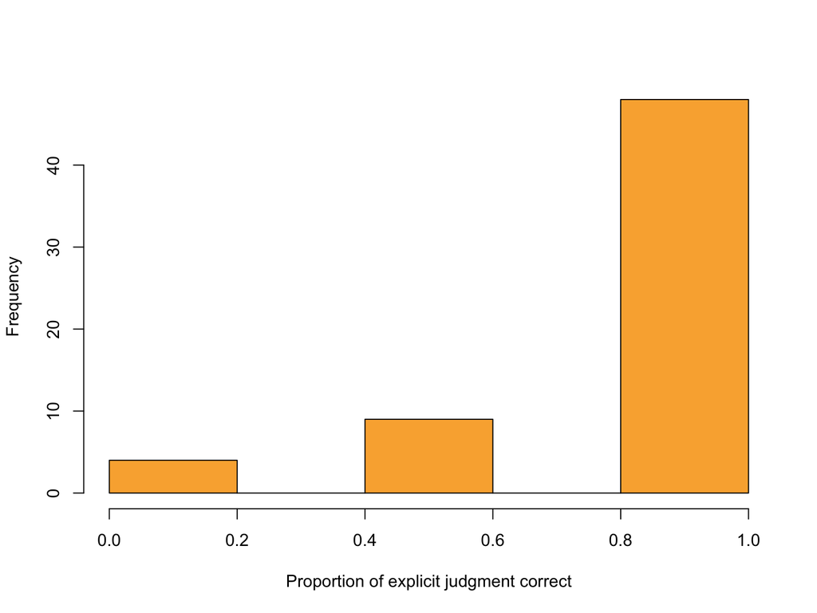

Proportion of Ask Questions correct

| Min. | 1st Qu. | Median | Mean | 3rd Qu. | Max. |
| --- | --- | --- | --- | --- | --- |
| 0 | 0.5 | 0.75 | 0.6257 | 0.75 | 1 |

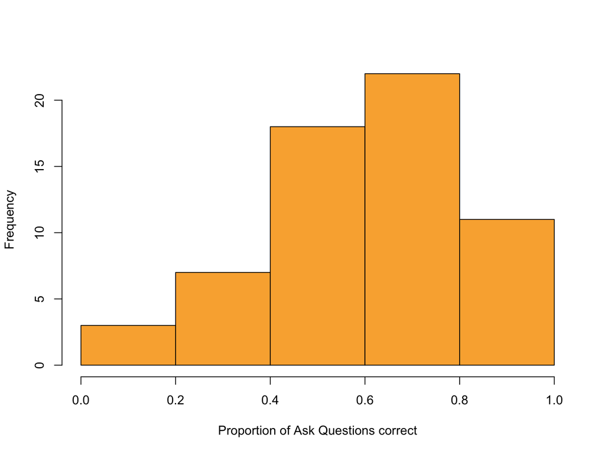

Proportion of Endorsement Questions correct

| Min. | 1st Qu. | Median | Mean | 3rd Qu. | Max. | NA’s |
| --- | --- | --- | --- | --- | --- | --- |
| 0 | 0.4167 | 0.75 | 0.678 | 1 | 1 | 2 |

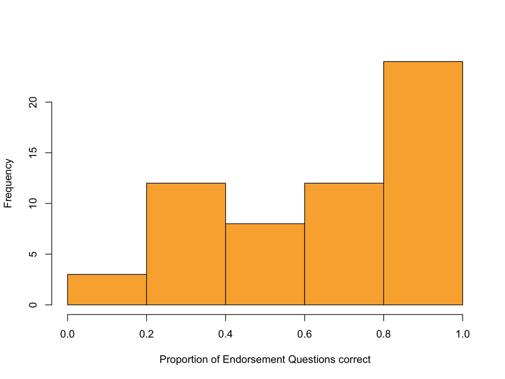

Performance across all questions

| Min. | 1st Qu. | Median | Mean | 3rd Qu. | Max. |
| --- | --- | --- | --- | --- | --- |
| 0.125 | 0.5 | 0.625 | 0.6407 | 0.7778 | 1 |

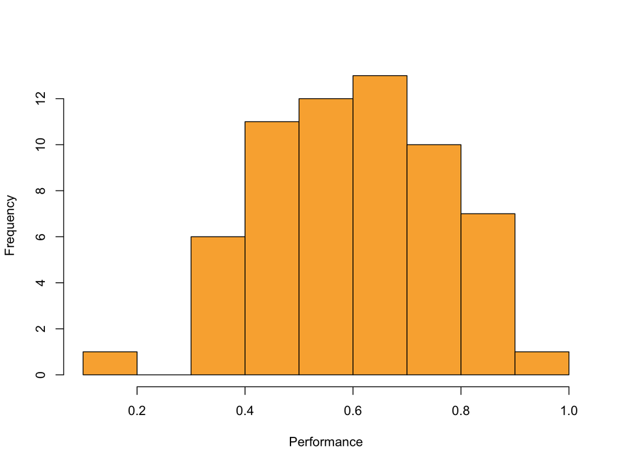

| Question | Proportion | t.df. | X95.CI |
| --- | --- | --- | --- |
| Explicit judgment | 0.86(0.04) | 9.69(60) | 0.79,0.94 |
| Ask | 0.63(0.03) | 3.66(60) | 0.56,0.69 |
| Endorse | 0.68(0.04) | 4.14(58) | 0.59,0.76 |

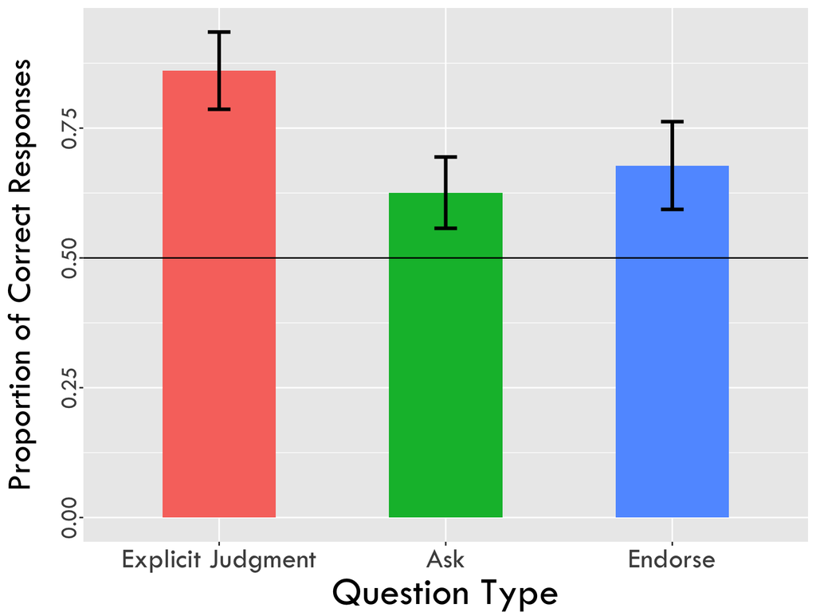

```
##
##  One Sample t-test
##
## data:  WL1$EJ.Purple
## t = -0.83, df = 60, p-value = 0.4
## alternative hypothesis: true mean is not equal to 0.5
## 95 percent confidence interval:
##  0.3323 0.5694
## sample estimates:
## mean of x
##    0.4508
```

```
##
##  One Sample t-test
##
## data:  WL1$Ask.Purple
## t = 1.6, df = 60, p-value = 0.1
## alternative hypothesis: true mean is not equal to 0.5
## 95 percent confidence interval:
##  0.4858 0.6345
## sample estimates:
## mean of x
##    0.5601
```

```
##
##  One Sample t-test
##
## data:  WL1$Word.Purple
## t = -0.93, df = 58, p-value = 0.4
## alternative hypothesis: true mean is not equal to 0.5
## 95 percent confidence interval:
##  0.3577 0.5519
## sample estimates:
## mean of x
##    0.4548
```

```
##
##  One Sample t-test
##
## data:  WL1$EJ.Orange
## t = 0.83, df = 60, p-value = 0.4
## alternative hypothesis: true mean is not equal to 0.5
## 95 percent confidence interval:
##  0.4306 0.6677
## sample estimates:
## mean of x
##    0.5492
```

```
##
##  One Sample t-test
##
## data:  WL1$Ask.Orange
## t = -1.6, df = 60, p-value = 0.1
## alternative hypothesis: true mean is not equal to 0.5
## 95 percent confidence interval:
##  0.3655 0.5142
## sample estimates:
## mean of x
##    0.4399
```

```
##
##  One Sample t-test
##
## data:  WL1$Word.Orange
## t = 0.93, df = 58, p-value = 0.4
## alternative hypothesis: true mean is not equal to 0.5
## 95 percent confidence interval:
##  0.4481 0.6423
## sample estimates:
## mean of x
##    0.5452
```

```
##
##  Pearson's product-moment correlation
##
## data:  WL1$AgIndex and WL1$ExpIndex
## t = 1.8, df = 49, p-value = 0.08
## alternative hypothesis: true correlation is not equal to 0
## 95 percent confidence interval:
##  -0.03298  0.48752
## sample estimates:
##    cor
## 0.2448
```

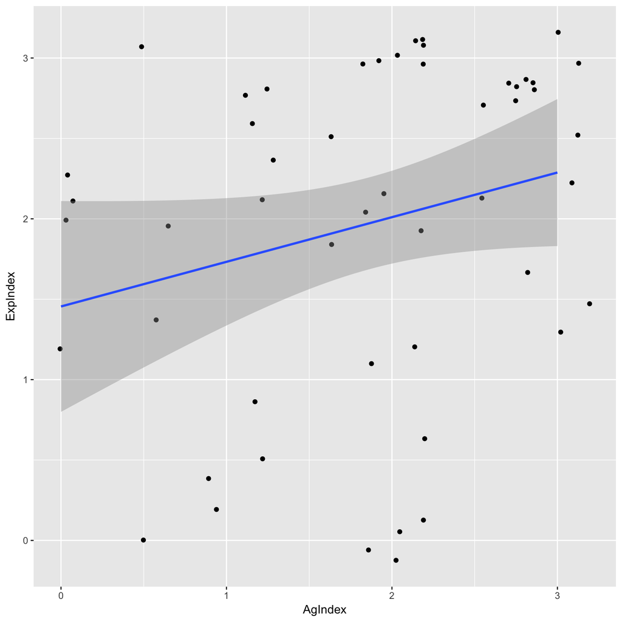

```
##
##  Pearson's product-moment correlation
##
## data:  WL1$Age and WL1$ExpIndex
## t = 1, df = 50, p-value = 0.3
## alternative hypothesis: true correlation is not equal to 0
## 95 percent confidence interval:
##  -0.1378  0.3981
## sample estimates:
##    cor
## 0.1404
```

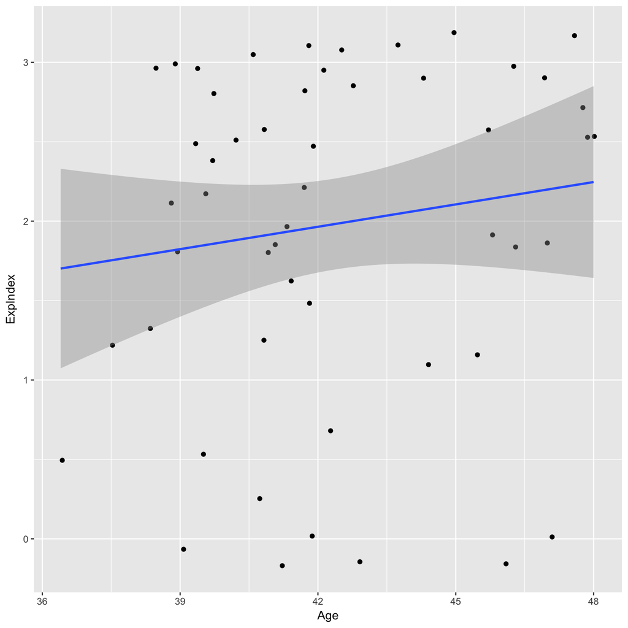

```
##
##  Pearson's product-moment correlation
##
## data:  WL1$Ask.Match and WL1$ExpIndex
## t = 1.1, df = 50, p-value = 0.3
## alternative hypothesis: true correlation is not equal to 0
## 95 percent confidence interval:
##  -0.1224  0.4111
## sample estimates:
##    cor
## 0.1557
```

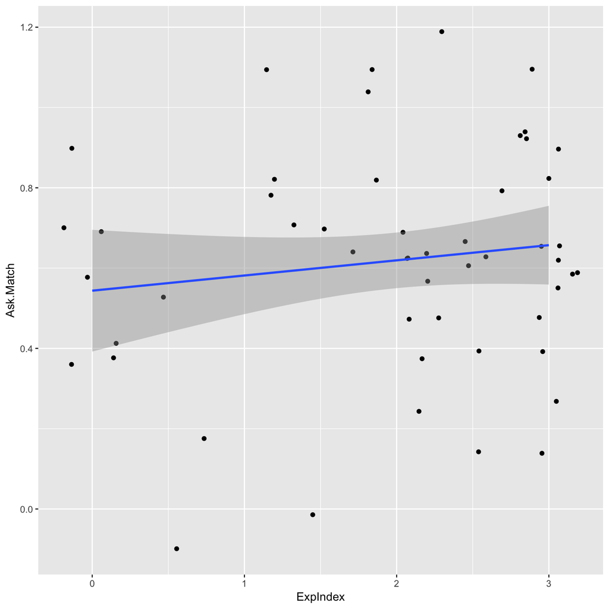

```
##
##  Pearson's product-moment correlation
##
## data:  WL1$Word.Match and WL1$ExpIndex
## t = 0.62, df = 48, p-value = 0.5
## alternative hypothesis: true correlation is not equal to 0
## 95 percent confidence interval:
##  -0.1939  0.3587
## sample estimates:
##     cor
## 0.08931
```

[figure not shown]

```
##
##  Pearson's product-moment correlation
##
## data:  WL1$Age and WL1$AgIndex
## t = 0.068, df = 50, p-value = 0.9
## alternative hypothesis: true correlation is not equal to 0
## 95 percent confidence interval:
##  -0.2640  0.2818
## sample estimates:
##      cor
## 0.009606
```

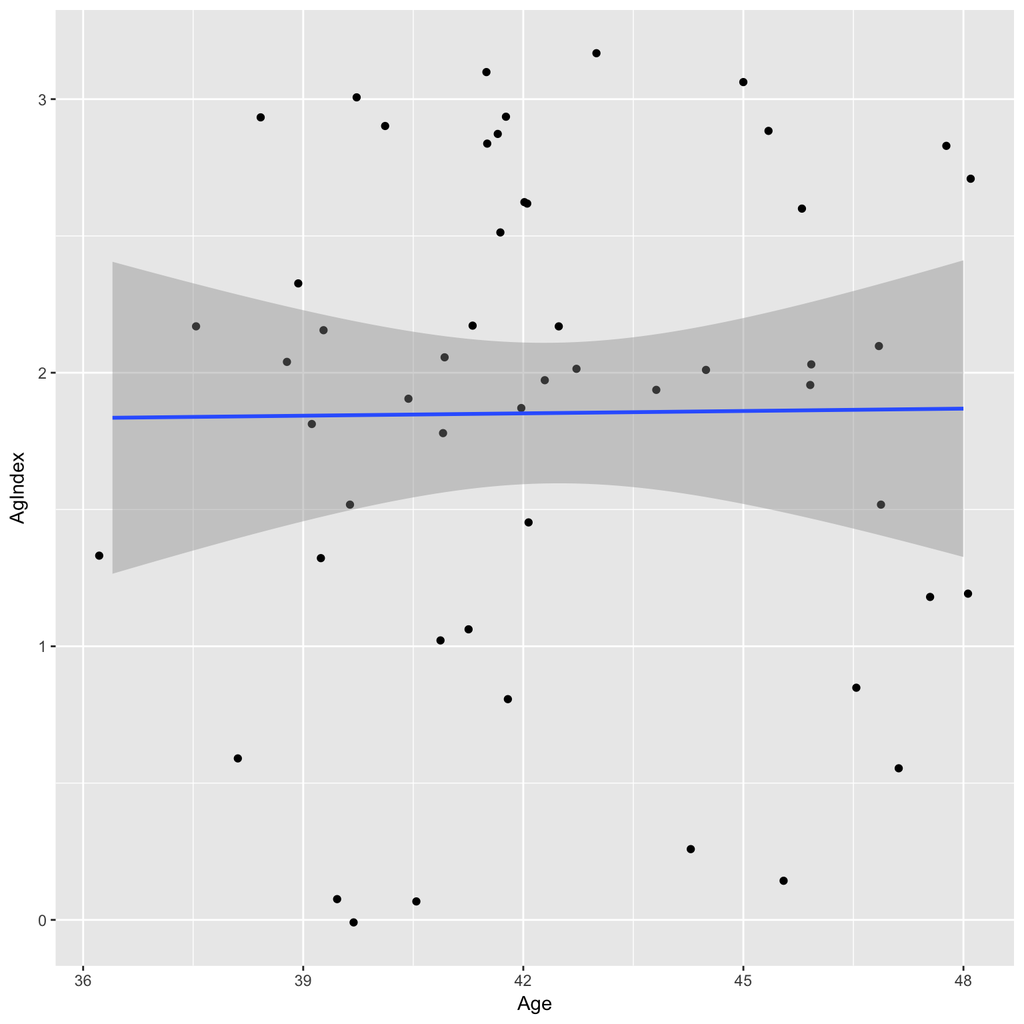

```
##
##  Pearson's product-moment correlation
##
## data:  WL1$Ask.Match and WL1$AgIndex
## t = 1.9, df = 50, p-value = 0.06
## alternative hypothesis: true correlation is not equal to 0
## 95 percent confidence interval:
##  -0.008829  0.501389
## sample estimates:
##    cor
## 0.2647
```

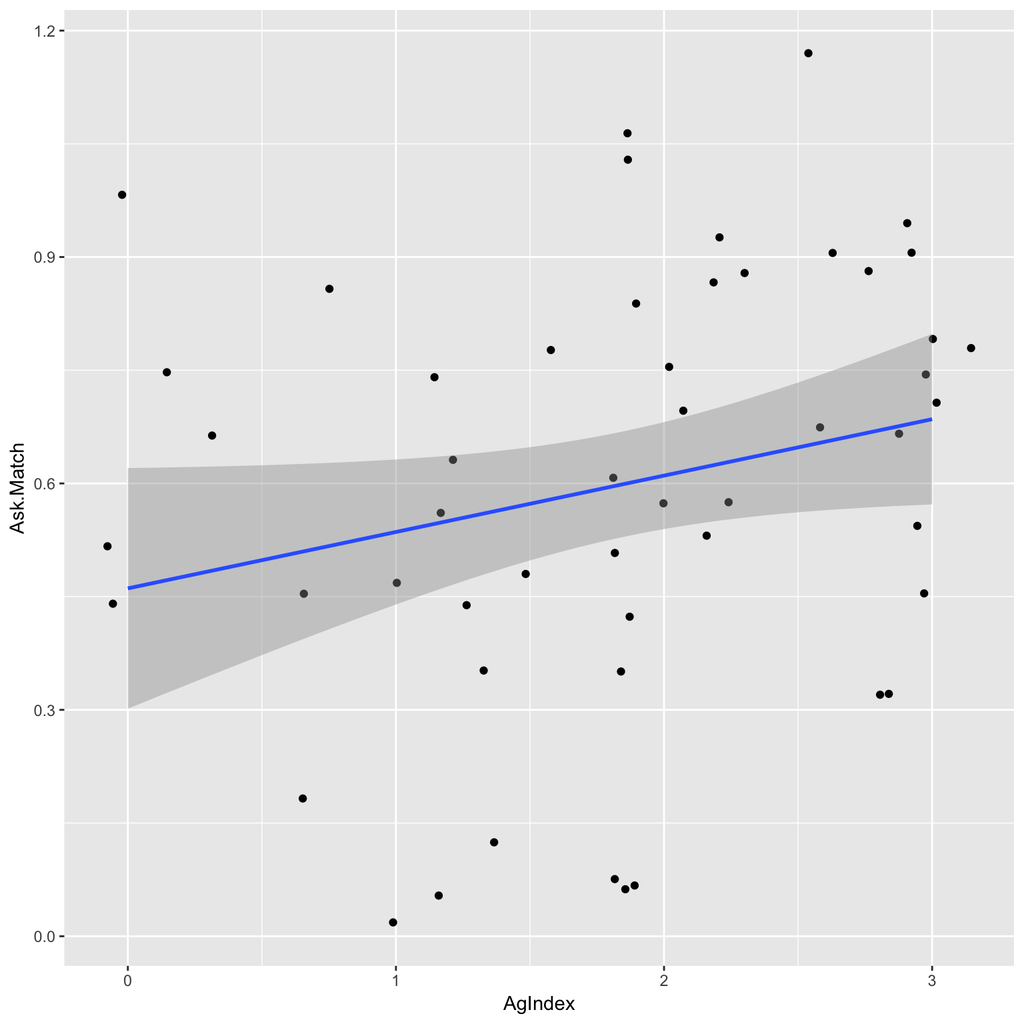

```
##
##  Pearson's product-moment correlation
##
## data:  WL1$Word.Match and WL1$AgIndex
## t = 1.5, df = 48, p-value = 0.1
## alternative hypothesis: true correlation is not equal to 0
## 95 percent confidence interval:
##  -0.07053  0.46301
## sample estimates:
##   cor
## 0.212
```

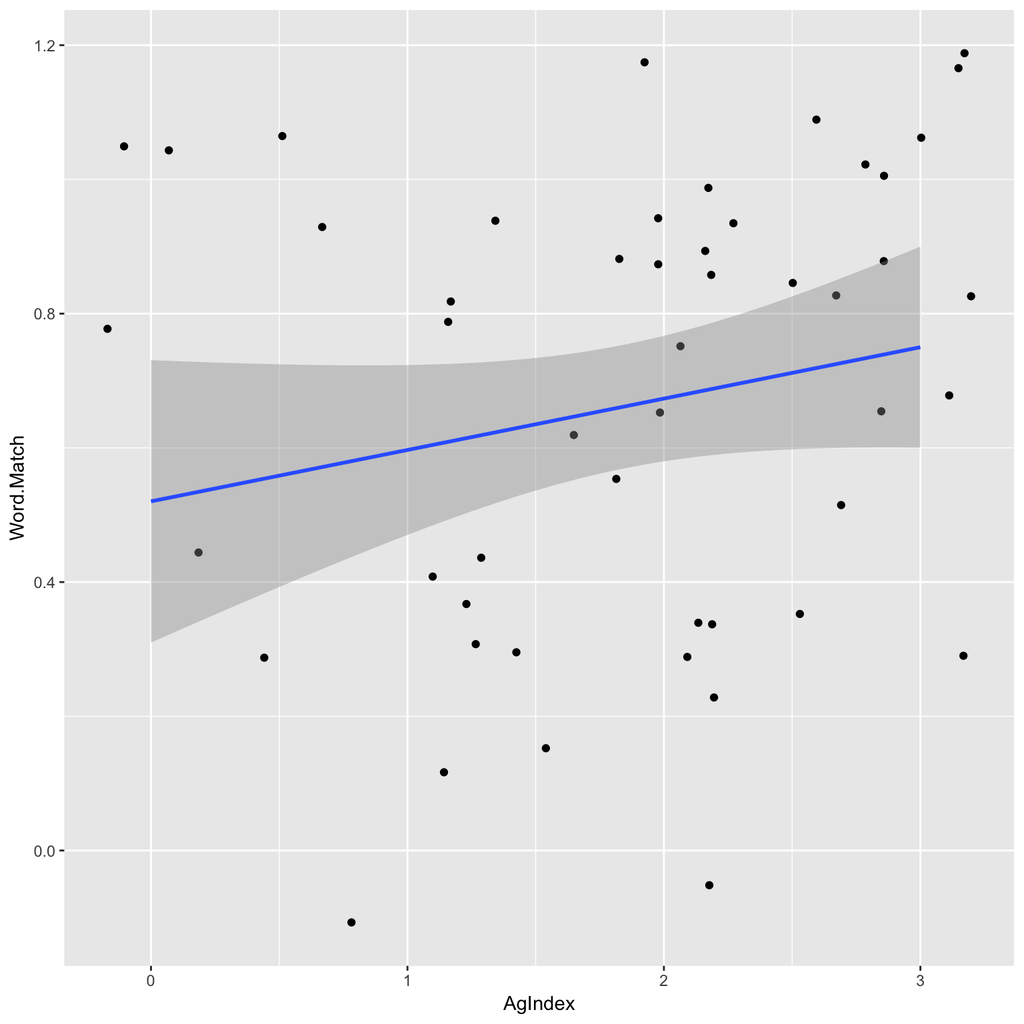

# Predicting Total Correct

```
##
##  Pearson's product-moment correlation
##
## data:  WL1$Total and WL1$AgIndex
## t = 3.4, df = 50, p-value = 0.001
## alternative hypothesis: true correlation is not equal to 0
## 95 percent confidence interval:
##  0.1822 0.6317
## sample estimates:
##    cor
## 0.4335
```

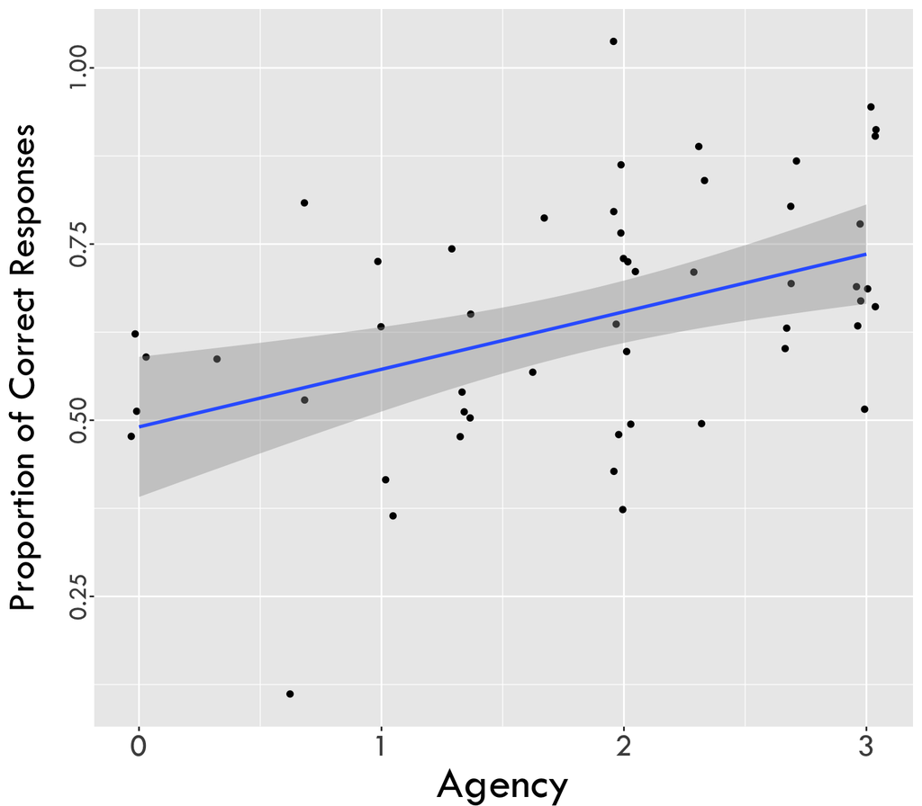

```
##
##  Pearson's product-moment correlation
##
## data:  WL1$Total and WL1$ExpIndex
## t = 0.037, df = 50, p-value = 1
## alternative hypothesis: true correlation is not equal to 0
## 95 percent confidence interval:
##  -0.2681  0.2777
## sample estimates:
##      cor
## 0.005212
```

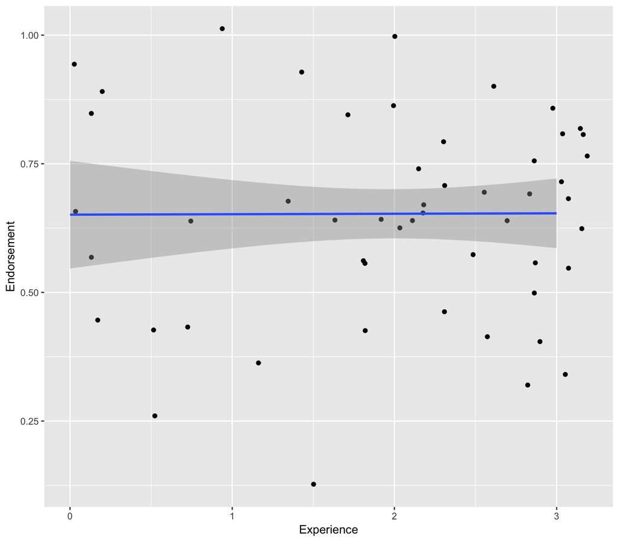

## Regression Analyses

```
##
## Call:
## glm(formula = Total ~ ExpIndex.cent + AgIndex.cent, data = WL1)
##
## Deviance Residuals:
##     Min       1Q   Median       3Q      Max
## -0.4364  -0.0990  -0.0068   0.1052   0.3234
##
## Coefficients:
##               Estimate Std. Error t value            Pr(>|t|)
## (Intercept)     0.6463     0.0217   29.76 <0.0000000000000002 ***
## ExpIndex.cent  -0.0189     0.0223   -0.85              0.4008
## AgIndex.cent    0.0757     0.0228    3.31              0.0018 **
## ---
## Signif. codes:  0 '***' 0.001 '**' 0.01 '*' 0.05 '.' 0.1 ' ' 1
##
## (Dispersion parameter for gaussian family taken to be 0.02396)
##
##     Null deviance: 1.4134  on 50  degrees of freedom
## Residual deviance: 1.1501  on 48  degrees of freedom
##   (10 observations deleted due to missingness)
## AIC: -40.66
##
## Number of Fisher Scoring iterations: 2
```

```
## ExpIndex.cent  AgIndex.cent
##       -0.1138        0.4451
```

```
##
## Call:
## glm(formula = Total ~ ExpIndex.cent + AgIndex.cent + Age.cent,
##     data = WL1)
##
## Deviance Residuals:
##     Min       1Q   Median       3Q      Max
## -0.3939  -0.0938   0.0100   0.0962   0.2987
##
## Coefficients:
##               Estimate Std. Error t value            Pr(>|t|)
## (Intercept)     0.6479     0.0215   30.15 <0.0000000000000002 ***
## ExpIndex.cent  -0.0239     0.0223   -1.07              0.2900
## AgIndex.cent    0.0768     0.0226    3.40              0.0014 **
## Age.cent        0.0335     0.0228    1.47              0.1491
## ---
## Signif. codes:  0 '***' 0.001 '**' 0.01 '*' 0.05 '.' 0.1 ' ' 1
##
## (Dispersion parameter for gaussian family taken to be 0.0234)
##
##     Null deviance: 1.4134  on 50  degrees of freedom
## Residual deviance: 1.0998  on 47  degrees of freedom
##   (10 observations deleted due to missingness)
## AIC: -40.94
##
## Number of Fisher Scoring iterations: 2
```

```
##
## Call:
## glm(formula = Total ~ ExpIndex.cent + AgIndex.cent + Age.cent +
##     Sex, data = WL1)
##
## Deviance Residuals:
##     Min       1Q   Median       3Q      Max
## -0.3903  -0.0899   0.0048   0.0914   0.3026
##
## Coefficients:
##               Estimate Std. Error t value            Pr(>|t|)
## (Intercept)    0.64429    0.02833   22.74 <0.0000000000000002 ***
## ExpIndex.cent -0.02358    0.02262   -1.04              0.3026
## AgIndex.cent   0.07638    0.02292    3.33              0.0017 **
## Age.cent       0.03368    0.02308    1.46              0.1513
## SexMale        0.00889    0.04428    0.20              0.8419
## ---
## Signif. codes:  0 '***' 0.001 '**' 0.01 '*' 0.05 '.' 0.1 ' ' 1
##
## (Dispersion parameter for gaussian family taken to be 0.02389)
##
##     Null deviance: 1.4134  on 50  degrees of freedom
## Residual deviance: 1.0988  on 46  degrees of freedom
##   (10 observations deleted due to missingness)
## AIC: -38.99
##
## Number of Fisher Scoring iterations: 2
```

```
##
## Call:
## glm(formula = Total ~ ExpIndex.cent + AgIndex.cent + Age.cent +
##     Sex + Order, data = WL1)
##
## Deviance Residuals:
##     Min       1Q   Median       3Q      Max
## -0.4066  -0.0666   0.0067   0.0949   0.3086
##
## Coefficients:
##               Estimate Std. Error t value            Pr(>|t|)
## (Intercept)    0.65499    0.05052   12.97 <0.0000000000000002 ***
## ExpIndex.cent -0.00459    0.02338   -0.20               0.845
## AgIndex.cent   0.06281    0.02395    2.62               0.012 *
## Age.cent       0.03549    0.02302    1.54               0.131
## SexMale        0.03147    0.04592    0.69               0.497
## OrderB        -0.10504    0.05898   -1.78               0.082 .
## OrderC         0.00165    0.07038    0.02               0.981
## OrderD         0.03671    0.06323    0.58               0.565
## ---
## Signif. codes:  0 '***' 0.001 '**' 0.01 '*' 0.05 '.' 0.1 ' ' 1
##
## (Dispersion parameter for gaussian family taken to be 0.02236)
##
##     Null deviance: 1.41336  on 50  degrees of freedom
## Residual deviance: 0.96145  on 43  degrees of freedom
##   (10 observations deleted due to missingness)
## AIC: -39.8
##
## Number of Fisher Scoring iterations: 2
```

|  | Estimate | Std. Error | t value | Pr(>\|t\|) |
| --- | --- | --- | --- | --- |
| **ExpIndex.cent** | -0.004585 | 0.02338 | -0.1961 | 0.8455 |
| **AgIndex.cent** | 0.06281 | 0.02395 | 2.623 | 0.01201 |
| **Age.cent** | 0.03549 | 0.02302 | 1.541 | 0.1305 |
| **SexMale** | 0.03147 | 0.04592 | 0.6852 | 0.4969 |
| **OrderB** | -0.105 | 0.05898 | -1.781 | 0.08197 |
| **OrderC** | 0.001645 | 0.07038 | 0.02337 | 0.9815 |
| **OrderD** | 0.03671 | 0.06323 | 0.5806 | 0.5646 |
| **(Intercept)** | 0.655 | 0.05052 | 12.97 | 0.0000000000000001871 |

Fitting linear model: Total ~ ExpIndex.cent + AgIndex.cent + Age.cent + Sex + Order

| Observations | Residual Std. Error | $R^2$ | Adjusted $R^2$ |
| --- | --- | --- | --- |
| 51 | 0.1495 | 0.3197 | 0.209 |

```
## ExpIndex.cent  AgIndex.cent      Age.cent       SexMale        OrderB
##      -0.02757       0.36923       0.20245       0.09303            NA
##        OrderC        OrderD
##       0.00989       0.21579
```

```
##
## Call:
## glm(formula = Total ~ AgIndex.cent + Age.cent, data = WL1)
##
## Deviance Residuals:
##     Min       1Q   Median       3Q      Max
## -0.3797  -0.1018   0.0316   0.1149   0.3276
##
## Coefficients:
##              Estimate Std. Error t value            Pr(>|t|)
## (Intercept)    0.6420     0.0216   29.76 <0.0000000000000002 ***
## AgIndex.cent   0.0753     0.0220    3.42              0.0013 **
## Age.cent       0.0310     0.0229    1.35              0.1818
## ---
## Signif. codes:  0 '***' 0.001 '**' 0.01 '*' 0.05 '.' 0.1 ' ' 1
##
## (Dispersion parameter for gaussian family taken to be 0.02413)
##
##     Null deviance: 1.5105  on 51  degrees of freedom
## Residual deviance: 1.1823  on 49  degrees of freedom
##   (9 observations deleted due to missingness)
## AIC: -41.19
##
## Number of Fisher Scoring iterations: 2
```

```
##
## Call:
## glm(formula = Total.bin ~ ExpIndex.cent + AgIndex.cent + Age.cent +
##     Sex, family = "binomial", data = WL1)
##
## Deviance Residuals:
##    Min      1Q  Median      3Q     Max
## -1.996  -0.903  -0.277   0.893   1.884
##
## Coefficients:
##               Estimate Std. Error z value Pr(>|z|)
## (Intercept)     -0.473      0.426   -1.11   0.2671
## ExpIndex.cent   -0.478      0.341   -1.40   0.1612
## AgIndex.cent     1.147      0.409    2.80   0.0051 **
## Age.cent         0.306      0.347    0.88   0.3782
## SexMale          0.895      0.659    1.36   0.1743
## ---
## Signif. codes:  0 '***' 0.001 '**' 0.01 '*' 0.05 '.' 0.1 ' ' 1
##
## (Dispersion parameter for binomial family taken to be 1)
##
##     Null deviance: 70.681  on 50  degrees of freedom
## Residual deviance: 57.191  on 46  degrees of freedom
##   (10 observations deleted due to missingness)
## AIC: 67.19
##
## Number of Fisher Scoring iterations: 4
```

```
##
## Call:
## glm(formula = Total ~ MindIndex.cent, data = WL1)
##
## Deviance Residuals:
##     Min       1Q   Median       3Q      Max
## -0.4739  -0.1076   0.0011   0.1067   0.3745
##
## Coefficients:
##                Estimate Std. Error t value            Pr(>|t|)
## (Intercept)      0.6457     0.0231   27.96 <0.0000000000000002 ***
## MindIndex.cent   0.0422     0.0239    1.76               0.084 .
## ---
## Signif. codes:  0 '***' 0.001 '**' 0.01 '*' 0.05 '.' 0.1 ' ' 1
##
## (Dispersion parameter for gaussian family taken to be 0.02712)
##
##     Null deviance: 1.4134  on 50  degrees of freedom
## Residual deviance: 1.3290  on 49  degrees of freedom
##   (10 observations deleted due to missingness)
## AIC: -35.28
##
## Number of Fisher Scoring iterations: 2
```

```
##
## Call:
## glm(formula = Total ~ MindIndex.cent + Age.cent, data = WL1)
##
## Deviance Residuals:
##     Min       1Q   Median       3Q      Max
## -0.4426  -0.0979   0.0111   0.1181   0.3577
##
## Coefficients:
##                Estimate Std. Error t value            Pr(>|t|)
## (Intercept)      0.6469     0.0231   28.02 <0.0000000000000002 ***
## MindIndex.cent   0.0396     0.0240    1.65                0.11
## Age.cent         0.0260     0.0244    1.07                0.29
## ---
## Signif. codes:  0 '***' 0.001 '**' 0.01 '*' 0.05 '.' 0.1 ' ' 1
##
## (Dispersion parameter for gaussian family taken to be 0.02705)
##
##     Null deviance: 1.4134  on 50  degrees of freedom
## Residual deviance: 1.2983  on 48  degrees of freedom
##   (10 observations deleted due to missingness)
## AIC: -34.48
##
## Number of Fisher Scoring iterations: 2
```

```
##
## Call:
## glm(formula = Total ~ MindIndex.cent + Age.cent + Sex, data = WL1)
##
## Deviance Residuals:
##     Min       1Q   Median       3Q      Max
## -0.4329  -0.0896  -0.0030   0.1058   0.3663
##
## Coefficients:
##                Estimate Std. Error t value            Pr(>|t|)
## (Intercept)      0.6379     0.0303   21.06 <0.0000000000000002 ***
## MindIndex.cent   0.0394     0.0242    1.63                0.11
## Age.cent         0.0267     0.0246    1.08                0.28
## SexMale          0.0219     0.0473    0.46                0.65
## ---
## Signif. codes:  0 '***' 0.001 '**' 0.01 '*' 0.05 '.' 0.1 ' ' 1
##
## (Dispersion parameter for gaussian family taken to be 0.0275)
##
##     Null deviance: 1.4134  on 50  degrees of freedom
## Residual deviance: 1.2923  on 47  degrees of freedom
##   (10 observations deleted due to missingness)
## AIC: -32.71
##
## Number of Fisher Scoring iterations: 2
```

```
##
## Call:
## glm(formula = Total ~ MindIndex.cent + Sex, data = WL1)
##
## Deviance Residuals:
##     Min       1Q   Median       3Q      Max
## -0.4661  -0.1050   0.0089   0.0955   0.3823
##
## Coefficients:
##                Estimate Std. Error t value            Pr(>|t|)
## (Intercept)      0.6379     0.0304   21.02 <0.0000000000000002 ***
## MindIndex.cent   0.0421     0.0241    1.74               0.087 .
## SexMale          0.0190     0.0473    0.40               0.689
## ---
## Signif. codes:  0 '***' 0.001 '**' 0.01 '*' 0.05 '.' 0.1 ' ' 1
##
## (Dispersion parameter for gaussian family taken to be 0.0276)
##
##     Null deviance: 1.4134  on 50  degrees of freedom
## Residual deviance: 1.3246  on 48  degrees of freedom
##   (10 observations deleted due to missingness)
## AIC: -33.46
##
## Number of Fisher Scoring iterations: 2
```

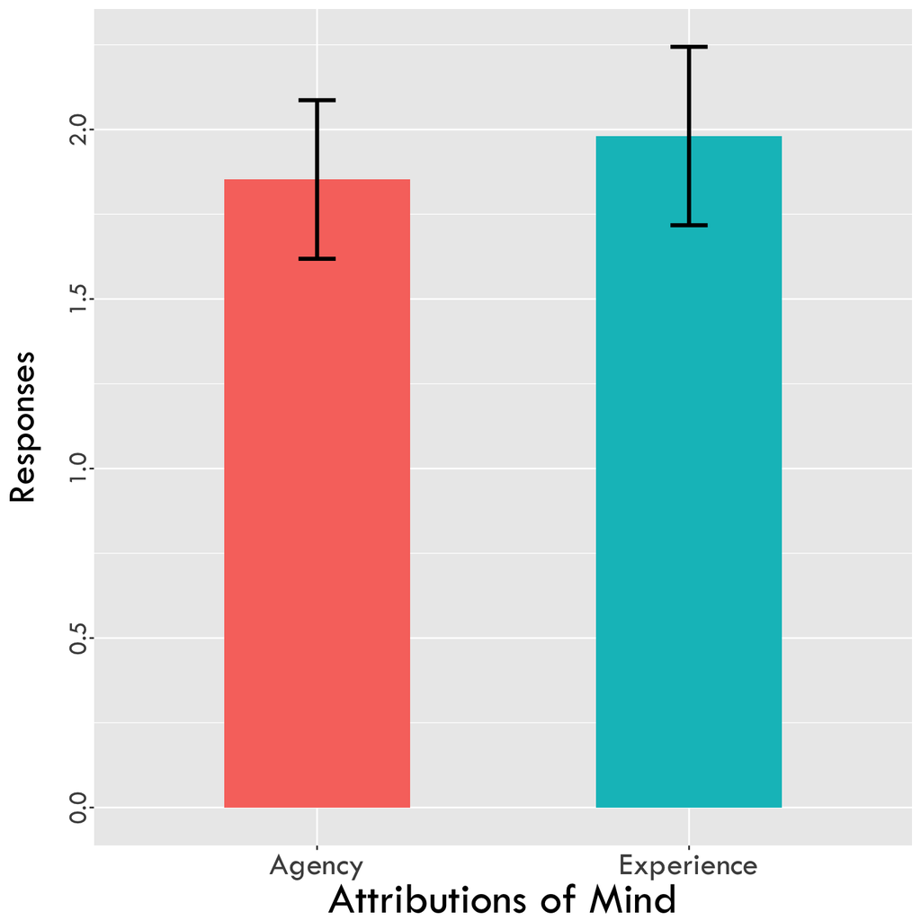